# IE582-Homework3

Hazal Hasret Yurdakul

19 November 2018

**TASK 1** **A**

There are 8 different gesture classes. Data includes the acceleration information so that we are going to find velocity vectors using this acceleration information. After that, we need to find position information using average speed values. The gestures generated by positions are classified and tested.

```r
library(data.table)
library(plot3D)

X_TEST <- read.table("uWaveGestureLibrary_X_TEST")
Y_TEST <- read.table("uWaveGestureLibrary_Y_TEST")
Z_TEST <- read.table("uWaveGestureLibrary_Z_TEST")

X_TRAIN <- read.table("uWaveGestureLibrary_X_TRAIN")
Y_TRAIN <- read.table("uWaveGestureLibrary_Y_TRAIN")
Z_TRAIN <- read.table("uWaveGestureLibrary_Z_TRAIN")

dim(X_TEST)
```

```
## [1] 3582  316
```

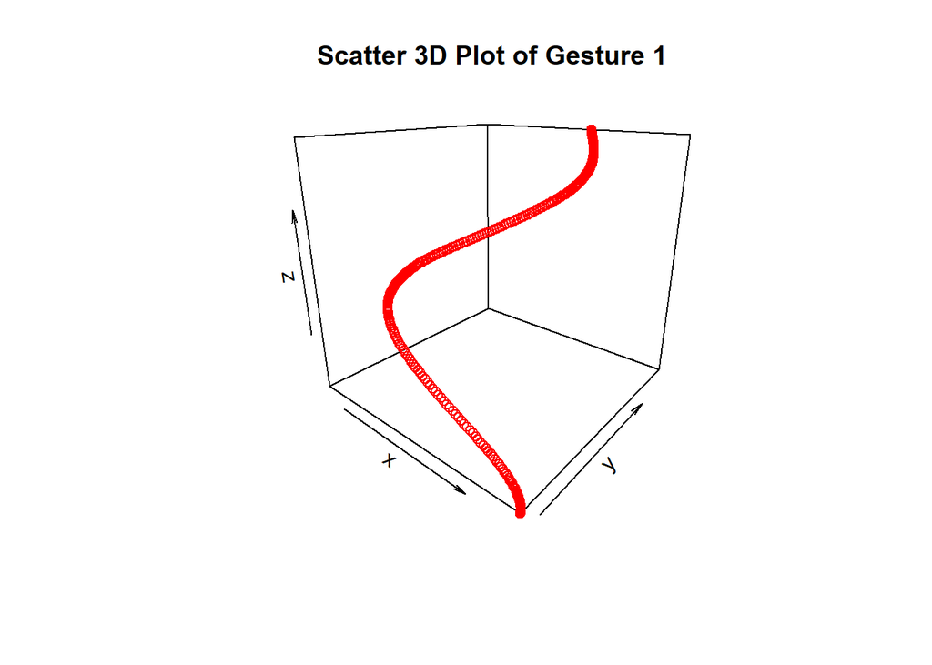

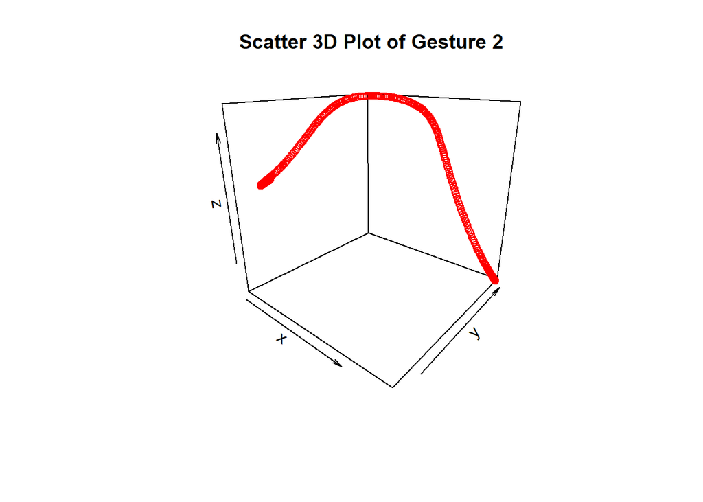

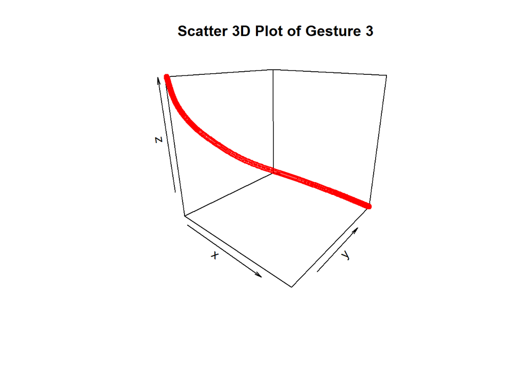

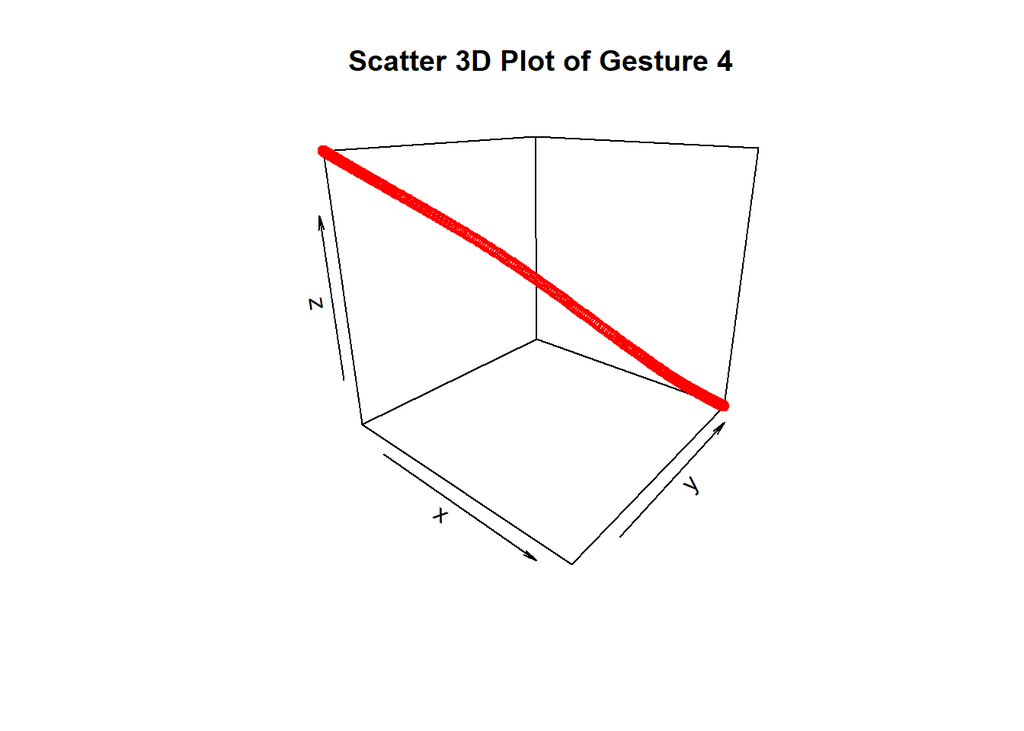

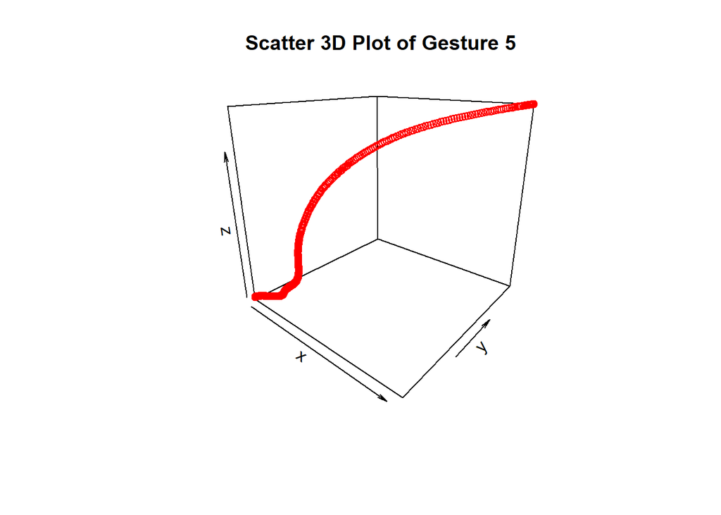

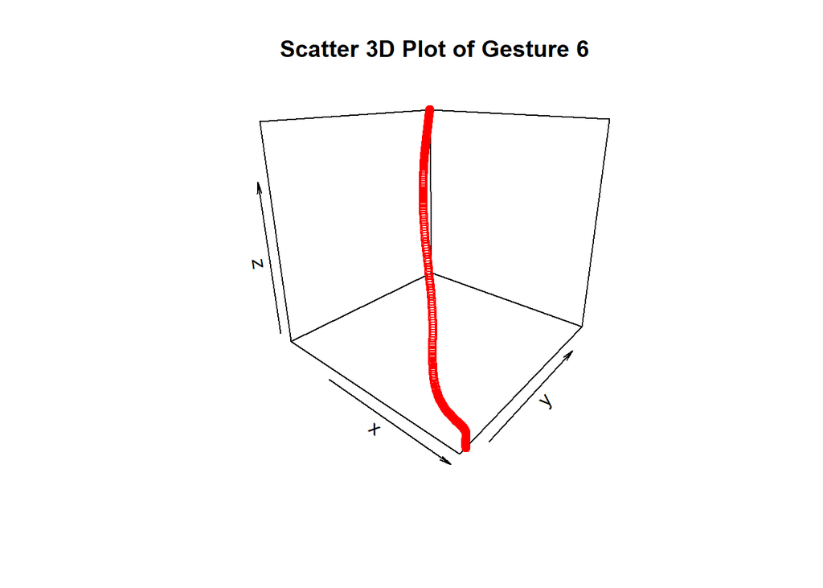

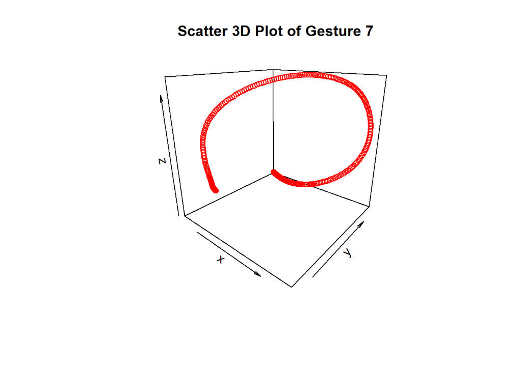

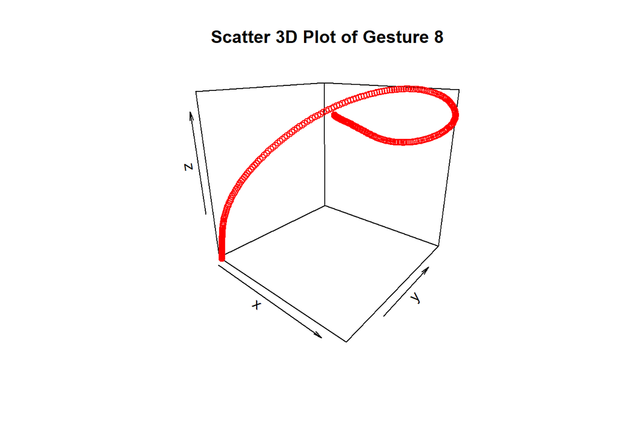

```r
# it is plotted for each gesture class

for (k in 1:8) {
    train.X <- X_TRAIN[X_TRAIN$V1 == k, ]
    train.Y <- Y_TRAIN[Y_TRAIN$V1 == k, ]
    train.Z <- Z_TRAIN[Z_TRAIN$V1 == k, ]

    # 5th gesture is selected to plot
    accelarationx <- train.X[5, 2:316]
    velocityx <- cumsum(as.list(accelarationx))  #cumulative sum of accelerations
    new.velocityx <- as.matrix(c(0, velocityx))  #start point is added as 0
    new.velocityx <- new.velocityx[-316, ]  #the last point is substracted
    average.speed.x <- (velocityx + new.velocityx)/2  #the average speed
    position.x <- cumsum(as.list(velocityx))  #cumulative sum of velocities
    # plot(average.speed.x)

    accelarationy <- train.Y[5, 2:316]
    velocityy <- cumsum(as.list(accelarationy))
    new.velocityy <- as.matrix(c(0, velocityy))
    new.velocityy <- new.velocityy[-316, ]
    average.speed.y <- (velocityy + new.velocityy)/2
    position.y <- cumsum(as.list(velocityy))
    # plot(position.y)

    accelarationz <- train.Z[5, 2:316]
    velocityz <- cumsum(as.list(accelarationz))
    new.velocityz <- as.matrix(c(0, velocityz))
    new.velocityz <- new.velocityz[-316, ]
    average.speed.z <- (velocityz + new.velocityz)/2
    position.z <- cumsum(as.list(velocityz))
    # plot(position.z)

    position.xyz <- cbind(position.x, position.y, position.z)
    scatter3D(position.x, position.y, position.z, col = 2, phi = 20,
        main = paste0("Scatter 3D Plot of Gesture ", k))
}
```

**TASK 1** **B**

We can use euclidean and manhattan distance measures for computing similarity between two time series.Training data will be used to identify the optimal value of k which minimizes the error of a 10-fold cross-validation. The distance matrix for each measurement is generated and scaled. Then, I applied KNN to the distance matrix with different k values.

```r
library(class)
library(caret)
library(kknn)
# drop first column for each
traindataX = X_TRAIN[, 2:ncol(X_TRAIN)]
traindataY = Y_TRAIN[, 2:ncol(Y_TRAIN)]
traindataZ = Z_TRAIN[, 2:ncol(Z_TRAIN)]

testdataX = X_TEST[, 2:ncol(X_TEST)]
testdataY = Y_TEST[, 2:ncol(Y_TEST)]
testdataZ = Z_TEST[, 2:ncol(Z_TEST)]

# combining X,Y,Z information columnwise
traindata = cbind(traindataX, traindataY, traindataZ)
testdata = cbind(testdataX, testdataY, testdataZ)
colnames(traindata) <- as.character(1:945)
colnames(testdata) <- as.character(1:945)
```

For euclidean distance, I tried 20 k values to find its optimal value. Misclassification error which is the mean of misclassified instances is calculated and plotted for each k.

```r
set.seed(123)
y = X_TRAIN$V1
idx <- createFolds(y, k = 10)  #creating 10 folds
sapply(idx, length)  #shows the number of instants of each fold
```

```
## Fold01 Fold02 Fold03 Fold04 Fold05 Fold06 Fold07 Fold08 Fold09 Fold10
##     89     90     90     90     89     89     89     90     89     91
```

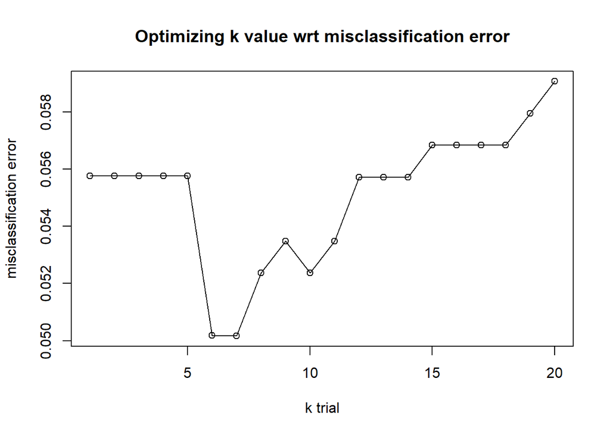

```r
start.time <- Sys.time()
k.trials <- 1:20
res <- sapply(k.trials, function(k) {
    ## try out each version of k from 1 to 20
    res.k <- sapply(seq_along(idx), function(i) {
        ## loop over each of the 10 cross-validation folds predict the
        ## held-out samples using k nearest neighbors
        pred = kknn(as.factor(y[-idx[[i]]]) ~ ., as.data.frame(traindata[-idx[[i]],
            ]), as.data.frame(traindata[idx[[i]], ]), k = k,
            distance = 2)
        ## the ratio of misclassified samples
        mean(as.factor(y[idx[[i]]]) != pred$fit)
    })
    ## average over the 10 folds
    mean(res.k)
})
end.time <- Sys.time()
time.taken <- end.time - start.time

plot(k.trials, res, type = "o", ylab = "misclassification error",
    xlab = "k trial", main = "Optimizing k value wrt misclassification error")
```

```r
which(res == min(res))
```

```
## [1] 7
```

As you can see, k=7 gives the minimum error for euclidean distance.Also, k=6 can be another option since it has a close error value. Runtime is given in below:

```r
time.taken
```

```
## Time difference of 2.212964 mins
```

For manhattan distance:

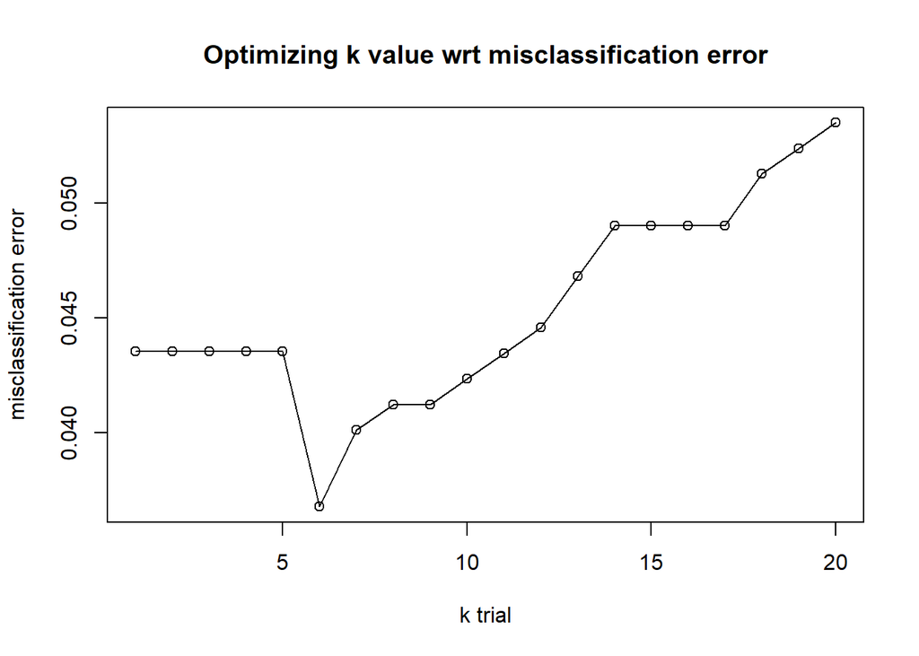

```r
k.trials <- 1:20

start.time <- Sys.time()
res <- sapply(k.trials, function(k) {
    ## try out each version of k from 1 to 12
    res.k <- sapply(seq_along(idx), function(i) {
        ## loop over each of the 10 cross-validation folds predict the
        ## held-out samples using k nearest neighbors
        pred = kknn(as.factor(y[-idx[[i]]]) ~ ., as.data.frame(traindata[-idx[[i]],
            ]), as.data.frame(traindata[idx[[i]], ]), k = k,
            distance = 1)
        ## the ratio of misclassified samples
        mean(as.factor(y[idx[[i]]]) != pred$fit)
    })
    ## average over the 10 folds
    mean(res.k)
})
end.time <- Sys.time()
time.taken <- end.time - start.time

plot(k.trials, res, type = "o", ylab = "misclassification error",
    xlab = "k trial", main = "Optimizing k value wrt misclassification error")
```

```r
which(res == min(res))
```

```
## [1] 6
```

As you can see, k=6 gives the minimum error for manhattan distance.Runtime is given below:

```r
time.taken
```

```
## Time difference of 6.835903 mins
```

**TASK 1** **C**

Using the value of k for each distance measure, we can generate 8x8 confusion matrix for the test data which shows the counts for actual and predicted labels. Furthermore, runtime and accuracy of the results will be given.

```r
# Test set Statistics

# euclidean
pred = kknn(as.factor(y) ~ ., as.data.frame(traindata[, ]), as.data.frame(testdata[,
    ]), k = 7, distance = 2)
mean(as.factor(X_TEST$V1) != pred$fit)
```

```
## [1] 0.05499721
```

```r
confusionMatrix(pred$fit, as.factor(X_TEST$V1))  #check accuracy
```

```
## Confusion Matrix and Statistics
##
##           Reference
## Prediction   1   2   3   4   5   6   7   8
##          1 430   1   2   6   3   4   0   0
##          2   0 449   0   0   0   0   0   0
##          3   0   0 416   0   8   4   3   0
##          4   2   0   0 371   1  14   0   2
##          5   0   0  16  58 419  28   0   1
##          6   4   0  15   7   2 399   0   0
##          7   1   2   5   0   0   0 444   0
##          8   0   0   0   8   0   0   0 457
##
## Overall Statistics
##
##                Accuracy : 0.945
##                  95% CI : (0.937, 0.9522)
##     No Information Rate : 0.1284
##     P-Value [Acc > NIR] : < 2.2e-16
##
##                   Kappa : 0.9372
##  Mcnemar's Test P-Value : NA
##
## Statistics by Class:
##
##                      Class: 1 Class: 2 Class: 3 Class: 4 Class: 5 Class: 6
## Sensitivity            0.9840   0.9934   0.9163   0.8244   0.9677   0.8886
## Specificity            0.9949   1.0000   0.9952   0.9939   0.9673   0.9911
## Pos Pred Value         0.9641   1.0000   0.9652   0.9513   0.8027   0.9344
## Neg Pred Value         0.9978   0.9990   0.9879   0.9753   0.9954   0.9842
## Prevalence             0.1220   0.1262   0.1267   0.1256   0.1209   0.1253
## Detection Rate         0.1200   0.1253   0.1161   0.1036   0.1170   0.1114
## Detection Prevalence   0.1245   0.1253   0.1203   0.1089   0.1457   0.1192
## Balanced Accuracy      0.9894   0.9967   0.9558   0.9092   0.9675   0.9399
##                      Class: 7 Class: 8
## Sensitivity            0.9933   0.9935
## Specificity            0.9974   0.9974
## Pos Pred Value         0.9823   0.9828
## Neg Pred Value         0.9990   0.9990
## Prevalence             0.1248   0.1284
## Detection Rate         0.1240   0.1276
## Detection Prevalence   0.1262   0.1298
## Balanced Accuracy      0.9954   0.9955
```

```r
# manhattan
pred = kknn(as.factor(y) ~ ., as.data.frame(traindata[, ]), as.data.frame(testdata[,
    ]), k = 6, distance = 1)
mean(as.factor(X_TEST$V1) != pred$fit)
```

```
## [1] 0.04690117
```

```r
confusionMatrix(pred$fit, as.factor(X_TEST$V1))  #check accuracy
```

```
## Confusion Matrix and Statistics
##
##           Reference
## Prediction   1   2   3   4   5   6   7   8
##          1 432   1   2   3   3   4   0   0
##          2   0 451   0   0   0   0   0   0
##          3   0   0 418   0   7   4   3   0
##          4   2   0   0 387   1  13   0   2
##          5   0   0  14  47 421  24   0   1
##          6   3   0  15   7   1 404   0   0
##          7   0   0   5   0   0   0 444   0
##          8   0   0   0   6   0   0   0 457
##
## Overall Statistics
##
##                Accuracy : 0.9531
##                  95% CI : (0.9457, 0.9598)
##     No Information Rate : 0.1284
##     P-Value [Acc > NIR] : < 2.2e-16
##
##                   Kappa : 0.9464
##  Mcnemar's Test P-Value : NA
##
## Statistics by Class:
##
##                      Class: 1 Class: 2 Class: 3 Class: 4 Class: 5 Class: 6
## Sensitivity            0.9886   0.9978   0.9207   0.8600   0.9723   0.8998
## Specificity            0.9959   1.0000   0.9955   0.9943   0.9727   0.9917
## Pos Pred Value         0.9708   1.0000   0.9676   0.9556   0.8304   0.9395
## Neg Pred Value         0.9984   0.9997   0.9886   0.9802   0.9961   0.9857
## Prevalence             0.1220   0.1262   0.1267   0.1256   0.1209   0.1253
## Detection Rate         0.1206   0.1259   0.1167   0.1080   0.1175   0.1128
## Detection Prevalence   0.1242   0.1259   0.1206   0.1131   0.1415   0.1200
## Balanced Accuracy      0.9922   0.9989   0.9581   0.9271   0.9725   0.9457
##                      Class: 7 Class: 8
## Sensitivity            0.9933   0.9935
## Specificity            0.9984   0.9981
## Pos Pred Value         0.9889   0.9870
## Neg Pred Value         0.9990   0.9990
## Prevalence             0.1248   0.1284
## Detection Rate         0.1240   0.1276
## Detection Prevalence   0.1253   0.1293
## Balanced Accuracy      0.9958   0.9958
```

For knn using euclidean distance with k=7, the accuracy is 0.945 which is quite good. Also, many misclassification errors are occured between 4,5 and 6th gesture classes. However, knn using manhattan distance with k=6 gives better accuracy which is 0.9531. The misclassifications of gesture classes are distributed in a similar way. Although accuracy of predictions using manhattan distance is slightly higher than using euclidean distance, manhattan distance requires much more runtime. Therefore, for big data, it is better to use euclidean distance.

**TASK 2** **A-B**

Logistic regression model is generated on the training data using fused lasso penalties. After that, model parameters are used to predict the classes for test data. Since “lqa” package is deleted from R, “penalized” package is used for training.

```r
library(penalized)
library(caret)

ECG.train = read.table("ecgTRAIN")
ECG.test = read.table("ecgTEST")

traindata = ECG.train[, 2:ncol(ECG.train)]
testdata = ECG.test[, 2:ncol(ECG.test)]

train.class = ECG.train$V1
test.class = ECG.test$V1

# changed class labels from (-1,1) to (0,1)

for (i in 1:length(train.class)) {
    if (train.class[i] < 0) {
        train.class[i] = 0
    } else {
        train.class[i] = 1
    }
}
```

Lambda1 controls the degree of sparsity and lambda2 controls the degree of smoothing between successive differences.We can find the best lambda1 and lambda2 values by trying different values.’optL1’ and ‘optL2’ functions included in ‘penalized’ package find optimum value of lambda1 and lambda2.

```r
lambda1 <- optL1(train.class, penalized = ~., data = traindata,
    fusedl = TRUE, minlambda1 = 0, maxlambda1 = 2, model = "logistic",
    fold = 10)
```

```
## lambda= 0.763932     12345678910cvl= -37.9428
## lambda= 1.236068     12345678910cvl= -37.91169
## lambda= 1.527864     12345678910cvl= -37.37883
## lambda= 1.708204     12345678910cvl= -37.3251
## lambda= 1.664062     12345678910cvl= -37.33235
## lambda= 1.769973     12345678910cvl= -37.29159
## lambda= 1.857836     12345678910cvl= -37.28658
## lambda= 1.822692     12345678910cvl= -37.28257
## lambda= 1.822683     12345678910cvl= -37.28256
## lambda= 1.80255  12345678910cvl= -37.28139
## lambda= 1.811441     12345678910cvl= -37.28176
## lambda= 1.793769     12345678910cvl= -37.28376
## lambda= 1.805946     12345678910cvl= -37.2815
## lambda= 1.799196     12345678910cvl= -37.28212
## lambda= 1.803847     12345678910cvl= -37.28143
## lambda= 1.801269     12345678910cvl= -37.28152
## lambda= 1.803045     12345678910cvl= -37.28141
## lambda= 1.802061     12345678910cvl= -37.28138
## lambda= 1.801758     12345678910cvl= -37.28145
## lambda= 1.802248     12345678910cvl= -37.28139
```

```r
lambda2 <- optL2(train.class, penalized = ~., data = traindata,
    lambda1 = lambda1$lambda, fusedl = TRUE, minlambda2 = 0,
    maxlambda2 = 2, model = "logistic", fold = 10)
```

```
## lambda= 2    12345678910cvl= -39.61894
## lambda= 0.763932     12345678910cvl= -39.29339
## lambda= 1.236068     12345678910cvl= -39.02987
## lambda= 1.527864     12345678910cvl= -39.17135
## lambda= 1.204402     12345678910cvl= -39.0475
## lambda= 1.306667     12345678910cvl= -39.03355
## lambda= 1.263034     12345678910cvl= -39.02821
## lambda= 1.261379     12345678910cvl= -39.02843
## lambda= 1.2797   12345678910cvl= -39.02698
## lambda= 1.283391     12345678910cvl= -39.02681
## lambda= 1.292281     12345678910cvl= -39.02647
## lambda= 1.297776     12345678910cvl= -39.02807
## lambda= 1.288885     12345678910cvl= -39.02659
## lambda= 1.29438  12345678910cvl= -39.02702
## lambda= 1.290984     12345678910cvl= -39.02651
## lambda= 1.293083     12345678910cvl= -39.02662
## lambda= 1.291786     12345678910cvl= -39.02648
## lambda= 1.292588     12345678910cvl= -39.02647
## lambda= 1.292187     12345678910cvl= -39.02647
```

```r
pen <- penalized(train.class, penalized = ~., data = traindata,
    lambda1 = lambda1$lambda, lambda2 = lambda2$lambda, model = "logistic",
    fusedl = TRUE)
```

```r
pen
```

```
## Penalized logistic regression object
## 97 regression coefficients of which 21 are non-zero
##
## Loglikelihood =   -28.43931
## L1 penalty =  8.105661   at lambda1 =  1.802061
## L2 penalty =  2.613733   at lambda2 =  1.292281
```

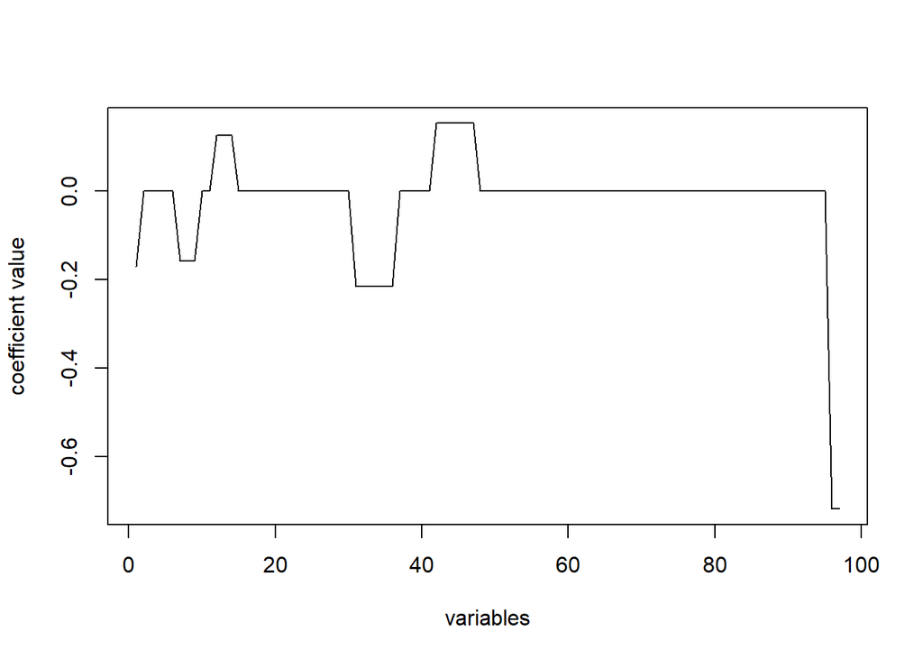

```r
plot(coefficients(pen, "all"), type = "l", xlab = "variables",
    ylab = "coefficient value")
```

```r
coefficients(pen)
```

```
## (Intercept)
##  -0.1703382  -0.1578716  -0.1578716  -0.1578716   0.1260537   0.1260537
##
##   0.1260537  -0.2154064  -0.2154064  -0.2154064  -0.2154064  -0.2154064
##
##  -0.2154064   0.1529816   0.1529816   0.1529816   0.1529816   0.1529816
##
##   0.1529816  -0.7179462  -0.7179462
```

Based on the graph, we can say that many coefficients are chosen as 0 while non-zero coefficients are chosen as to catch the difference between classes. Also, the algorithm chooses some coefficients conscecutively due to its nature.

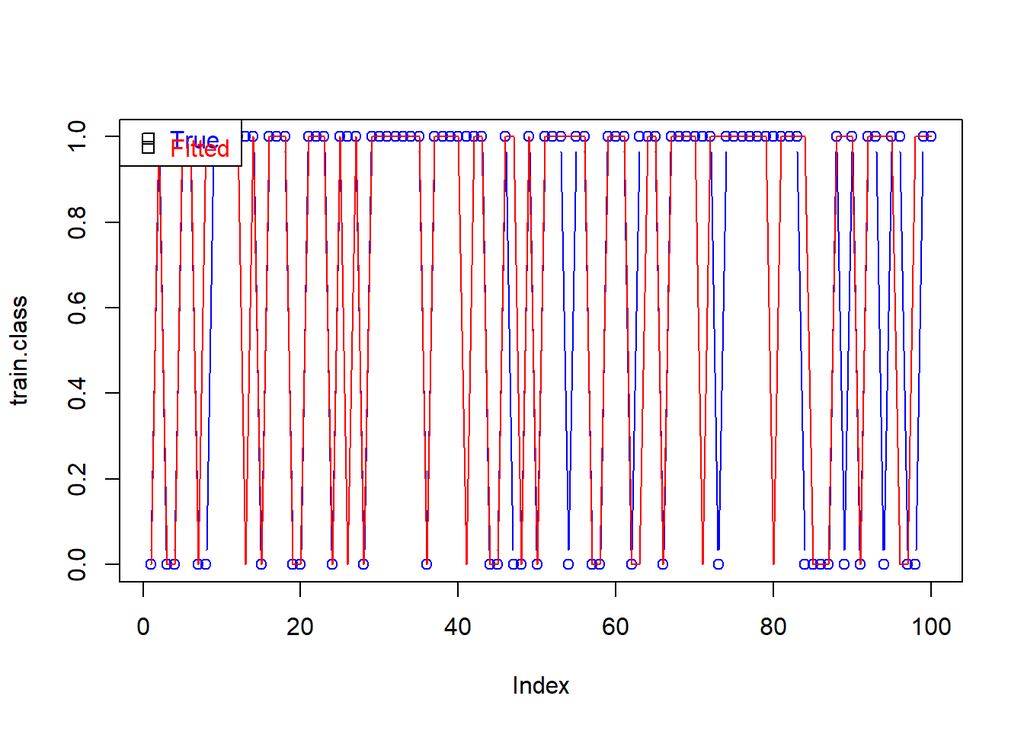

```r
prediction = predict(pen, penalized = ECG.train[, 2:ncol(ECG.train)])

for (i in 1:length(prediction)) {
    if (prediction[i] < 0.5) {
        prediction[i] = 0
    } else {
        prediction[i] = 1
    }
}

plot(train.class, col = "blue", type = "b", pch = 1)
lines(prediction, type = "l", lty = 1, col = "red")
legend("topleft", pch = 0.1, lty = 0.1, merge = TRUE, text.col = c("blue",
    "red"), legend = c("True", "Fitted"), xjust = 0.004, yjust = 0.004,
    x.intersp = 0, y.intersp = 0.3)
```

```r
confusionMatrix(factor(train.class), factor(prediction))  #check accuracy
```

```
## Confusion Matrix and Statistics
##
##           Reference
## Prediction  0  1
##          0 23  8
##          1  7 62
##
##                Accuracy : 0.85
##                  95% CI : (0.7647, 0.9135)
##     No Information Rate : 0.7
##     P-Value [Acc > NIR] : 0.000405
##
##                   Kappa : 0.6462
##  Mcnemar's Test P-Value : 1.000000
##
##             Sensitivity : 0.7667
##             Specificity : 0.8857
##          Pos Pred Value : 0.7419
##          Neg Pred Value : 0.8986
##              Prevalence : 0.3000
##          Detection Rate : 0.2300
##    Detection Prevalence : 0.3100
##       Balanced Accuracy : 0.8262
##
##        'Positive' Class : 0
##
```

Using this penalized model, I predict the classes of test data.The prediction values are given in a continuous form between 0 and 1. Therefore, I chose a threshold=0.5 to separate them.

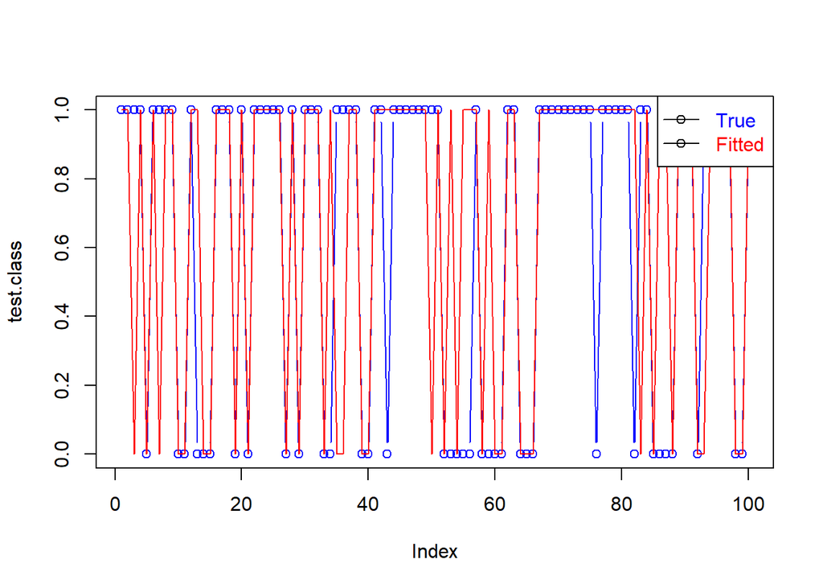

```r
for (i in 1:length(test.class)) {
    if (test.class[i] < 0) {
        test.class[i] = 0
    } else {
        test.class[i] = 1
    }
}

prediction.test = predict(pen, penalized = ECG.test[, 2:ncol(ECG.test)])

for (i in 1:length(prediction.test)) {
    if (prediction.test[i] < 0.5) {
        prediction.test[i] = 0
    } else {
        prediction.test[i] = 1
    }
}

plot(test.class, col = "blue", type = "b", pch = 1)
lines(prediction.test, type = "l", lty = 1, col = "red")
legend("topright", pch = 1, lty = 1, merge = TRUE, text.col = c("blue",
    "red"), legend = c("True", "Fitted"))
```

```r
confusionMatrix(factor(test.class), factor(prediction.test))
```

```
## Confusion Matrix and Statistics
##
##           Reference
## Prediction  0  1
##          0 25 11
##          1  7 57
##
##                Accuracy : 0.82
##                  95% CI : (0.7305, 0.8897)
##     No Information Rate : 0.68
##     P-Value [Acc > NIR] : 0.001247
##
##                   Kappa : 0.5996
##  Mcnemar's Test P-Value : 0.479500
##
##             Sensitivity : 0.7812
##             Specificity : 0.8382
##          Pos Pred Value : 0.6944
##          Neg Pred Value : 0.8906
##              Prevalence : 0.3200
##          Detection Rate : 0.2500
##    Detection Prevalence : 0.3600
##       Balanced Accuracy : 0.8097
##
##        'Positive' Class : 0
##
```

**TASK 2** **C-D**

We take the difference between consecutive time series observations to transform the time series.Since we take difference between columns, new vector has 97-1=96 columns. Then, we can apply same procedure.

```r
# generating difference vector (100x96) by just equating to
# older one
dif.ECG.train = ECG.train[, 2:97]

dif.ECG.train[, 1] = train.class
for (m in 2:96) {
    dif.ECG.train[, m] = ECG.train[, m + 1] - ECG.train[, m]
}

# for test
dif.ECG.test = ECG.test[, 2:97]
dif.ECG.test[, 1] = test.class
for (m in 2:96) {
    dif.ECG.test[, m] = ECG.test[, m + 1] - ECG.test[, m]
}

dif.traindata = dif.ECG.train[, 2:ncol(dif.ECG.train)]
dif.testdata = dif.ECG.test[, 2:ncol(dif.ECG.test)]

# apply same procedure
dif.lambda1 <- optL1(train.class, penalized = ~., data = dif.traindata,
    fusedl = TRUE, minlambda1 = 0, maxlambda1 = 1, model = "logistic",
    fold = 10)
```

```
## lambda= 0.381966     12345678910cvl= -54.28398
## lambda= 0.618034     12345678910cvl= -50.86136
## lambda= 0.763932     12345678910cvl= -49.50374
## lambda= 0.854102     12345678910cvl= -48.81495
## lambda= 0.9098301    12345678910cvl= -48.4128
## lambda= 0.9442719    12345678910cvl= -48.21303
## lambda= 0.9655581    12345678910cvl= -48.12013
## lambda= 0.9787138    12345678910cvl= -48.08304
## lambda= 0.9868444    12345678910cvl= -48.05513
## lambda= 0.9918694    12345678910cvl= -48.03694
## lambda= 0.994975     12345678910cvl= -48.02541
## lambda= 0.9968944    12345678910cvl= -48.01839
## lambda= 0.9980806    12345678910cvl= -48.01409
## lambda= 0.9988138    12345678910cvl= -48.01144
## lambda= 0.9992669    12345678910cvl= -48.00981
## lambda= 0.9995469    12345678910cvl= -48.00881
## lambda= 0.99972  12345678910cvl= -48.00819
## lambda= 0.9998269    12345678910cvl= -48.00781
```

```r
dif.lambda2 <- optL2(train.class, penalized = ~., lambda1 = dif.lambda1$lambda,
    data = dif.traindata, maxlambda2 = 1, model = "logistic",
    fold = 10)
```

```
## lambda= 1    12345678910cvl= -40.456
## lambda= 0.1  12345678910cvl= -40.56204
## lambda= 0.4437694    12345678910cvl= -40.32705
## lambda= 0.6562306    12345678910cvl= -40.28985
## lambda= 0.7875388    12345678910cvl= -40.32695
## lambda= 0.615772     12345678910cvl= -40.28365
## lambda= 0.5500729    12345678910cvl= -40.28936
## lambda= 0.6021248    12345678910cvl= -40.28335
## lambda= 0.6035872    12345678910cvl= -40.28333
## lambda= 0.6046482    12345678910cvl= -40.28333
## lambda= 0.6047776    12345678910cvl= -40.28333
## lambda= 0.6102101    12345678910cvl= -40.2834
## lambda= 0.6074291    12345678910cvl= -40.28335
## lambda= 0.6060387    12345678910cvl= -40.28333
## lambda= 0.6053434    12345678910cvl= -40.28333
## lambda= 0.6049958    12345678910cvl= -40.28333
## lambda= 0.604822     12345678910cvl= -40.28333
```

```r
pen <- penalized(train.class, penalized = ~., data = dif.traindata,
    lambda1 = dif.lambda1$lambda, lambda2 = dif.lambda2$lambda,
    model = "logistic", fusedl = TRUE)
```

```r
pen
```

```
## Penalized logistic regression object
## 96 regression coefficients of which 17 are non-zero
##
## Loglikelihood =   -31.09235
## L1 penalty =  9.637225   at lambda1 =  0.9998269
## L2 penalty =  3.032881   at lambda2 =  0.6047776
```

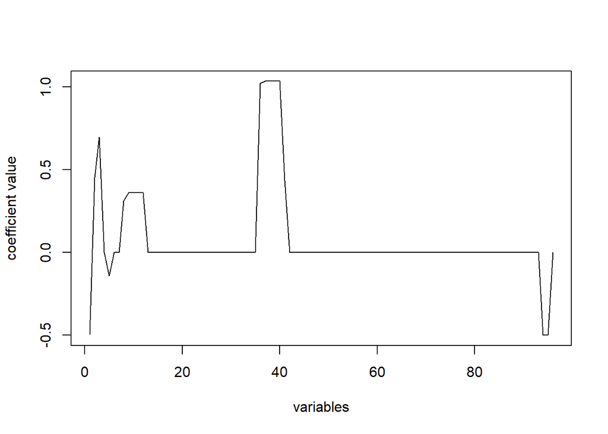

```r
plot(coefficients(pen, "all"), type = "l", xlab = "variables",
    ylab = "coefficient value")
```

```r
coefficients(pen)
```

```
## (Intercept)
##  -0.4949967   0.4520344   0.6952217  -0.1424553   0.3107884   0.3605801
##
##   0.3605801   0.3605801   0.3605801   1.0219045   1.0341850   1.0341850
##
##   1.0341850   1.0341850   0.4354080  -0.5010104  -0.5010104
```

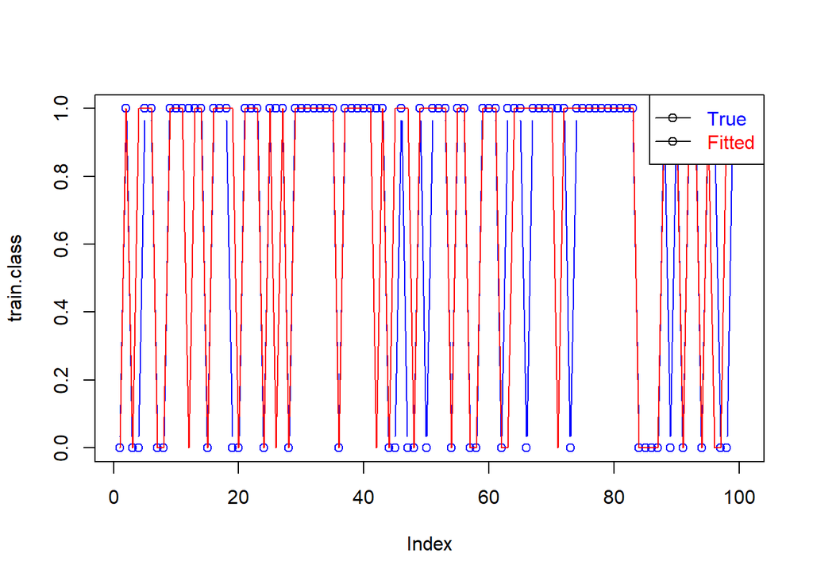

```r
prediction = predict(pen, penalized = dif.traindata)

for (i in 1:length(prediction)) {
    if (prediction[i] < 0.5) {
        prediction[i] = 0
    } else {
        prediction[i] = 1
    }
}

plot(train.class, col = "blue", type = "b", pch = 1)
lines(prediction, type = "l", lty = 1, col = "red")
legend("topright", pch = 1, lty = 1, merge = TRUE, text.col = c("blue",
    "red"), legend = c("True", "Fitted"))
```

```r
confusionMatrix(factor(train.class), factor(prediction))  #check accuracy
```

```
## Confusion Matrix and Statistics
##
##           Reference
## Prediction  0  1
##          0 22  9
##          1  6 63
##
##                Accuracy : 0.85
##                  95% CI : (0.7647, 0.9135)
##     No Information Rate : 0.72
##     P-Value [Acc > NIR] : 0.001678
##
##                   Kappa : 0.6398
##  Mcnemar's Test P-Value : 0.605577
##
##             Sensitivity : 0.7857
##             Specificity : 0.8750
##          Pos Pred Value : 0.7097
##          Neg Pred Value : 0.9130
##              Prevalence : 0.2800
##          Detection Rate : 0.2200
##    Detection Prevalence : 0.3100
##       Balanced Accuracy : 0.8304
##
##        'Positive' Class : 0
##
```

As you can see, coefficients of penalized model using differenced data become larger and number of coefficients decreases. We can say that consecutive differences make the coefficients smoother because data can have autocorrelation (means that behavior of the next data point depends on the previous one).

We do prediction for the differenced test data using the penalized model generated by training data.

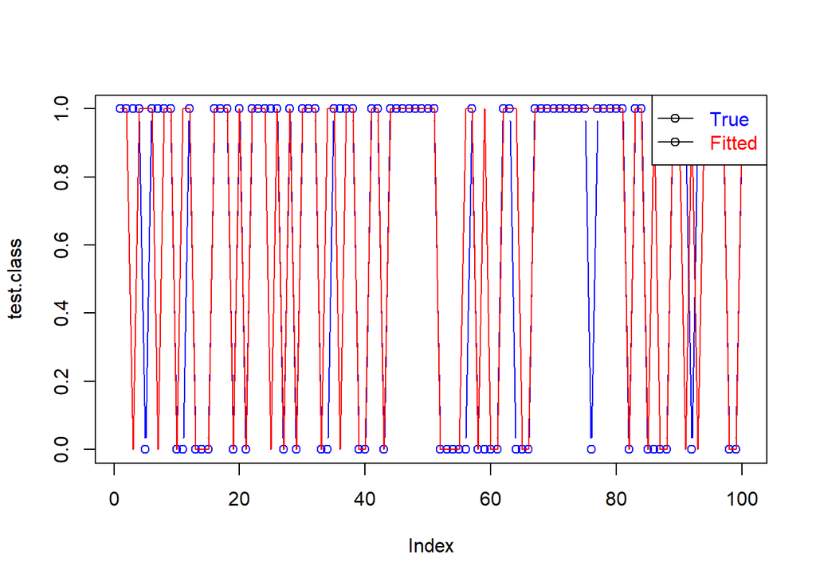

```r
prediction.test = predict(pen, penalized = dif.testdata)

for (i in 1:length(prediction.test)) {
    if (prediction.test[i] < 0.5) {
        prediction.test[i] = 0
    } else {
        prediction.test[i] = 1
    }
}

plot(test.class, col = "blue", type = "b", pch = 1)
lines(prediction.test, type = "l", lty = 1, col = "red")
legend("topright", pch = 1, lty = 1, merge = TRUE, text.col = c("blue",
    "red"), legend = c("True", "Fitted"))
```

```r
confusionMatrix(factor(test.class), factor(prediction.test))
```

```
## Confusion Matrix and Statistics
##
##           Reference
## Prediction  0  1
##          0 27  9
##          1  6 58
##
##                Accuracy : 0.85
##                  95% CI : (0.7647, 0.9135)
##     No Information Rate : 0.67
##     P-Value [Acc > NIR] : 3.791e-05
##
##                   Kappa : 0.6684
##  Mcnemar's Test P-Value : 0.6056
##
##             Sensitivity : 0.8182
##             Specificity : 0.8657
##          Pos Pred Value : 0.7500
##          Neg Pred Value : 0.9063
##              Prevalence : 0.3300
##          Detection Rate : 0.2700
##    Detection Prevalence : 0.3600
##       Balanced Accuracy : 0.8419
##
##        'Positive' Class : 0
##
```

The accuracy of predictions with differenced data is higher than undifferenced data. Therefore, this model is better.